# Evaluación de la expresión diferencial en muestras de CD4⁺ T cells con edgeR

Evaluación de la expresión diferencial en muestras de CD4⁺ T cells con edgeR Dra. Linda Aimara Kempis Calanis 2025-11-11

## Librerias a utilizar

```r
library(limma)
library(edgeR)
library(tximport)
library(ensembldb)
library(biomaRt)
library(EnhancedVolcano)
library(tidyverse)
```

## Leyendo los archivos .tsv

```r
# Obtiene una lista de todos los archivos en el directorio actual
# cuyo nombre coincide con el patrón ".tsv" (archivos de texto separados por tabulaciones).
FilesTSV<-list.files(pattern=".tsv")
FilesTSV
```

```
## [1] "A11.tsv" "A31.tsv" "A41.tsv" "N21.tsv" "N31.tsv" "N51.tsv"
```

## Ensembl

**useEnsembl()** proviene del paquete biomaRt, que conecta R con la base de datos Ensembl.

**getBM() (Get BioMart)** extrae datos según los attributes (columnas deseadas) y el objeto mart (la conexión).

La variable **tx2gene1** suele usarse en análisis de expresión génica (por ejemplo, con tximport) para **mapear transcritos a genes**.

**hgnc_symbol** proviene del HUGO Gene Nomenclature Committee, y es la forma estándar de nombrar genes humanos (por ejemplo, BRCA1, TP53).

```r
# Lee las primeras 10 filas del archivo TSV número 6 de la lista 'FilesTSV'
# Esto permite inspeccionar rápidamente la estructura del archivo (columnas, formato, etc.)
read.delim(FilesTSV[6], nrow=10)
```

```
##            target_id length eff_length est_counts tpm
## 1  ENST00000632684.1     12    6.31634          0   0
## 2  ENST00000434970.2      9    5.09167          0   0
## 3  ENST00000448914.1     13    6.71016          0   0
## 4  ENST00000415118.1      8    4.66863          0   0
## 5  ENST00000631435.1     12    6.31634          0   0
## 6  ENST00000390583.1     31   12.74430          0   0
## 7  ENST00000390577.1     37   14.39750          0   0
## 8  ENST00000451044.1     17    8.21713          0   0
## 9  ENST00000390578.1     31   12.74430          0   0
## 10 ENST00000390572.1     28   11.86010          0   0
```

Nombrar las variables ensembl y tx2gene y hacer una “traducción” a la nomenclatura hgnc_symbol

```r
# Conecta con la base de datos Ensembl (versión actual del servidor Ensembl)
# 'biomart = "ensembl"' indica el tipo de base de datos.
# 'dataset = "hsapiens_gene_ensembl"' especifica que se trabajará con genes humanos (Homo sapiens)
ensembl90 <- useEnsembl(biomart = 'ensembl', dataset="hsapiens_gene_ensembl")

# Obtiene una tabla con las relaciones entre los IDs de transcritos de Ensembl
# (incluyendo la versión del transcrito) y los símbolos de genes según HGNC (nomenclatura estándar de genes humanos).
# Esto sirve para "traducir" los identificadores técnicos de Ensembl a nombres de genes más legibles.
tx2gene1 <- getBM(attributes = c("ensembl_transcript_id_version", "hgnc_symbol"), mart = ensembl90)

# Muestra las dimensiones del data frame resultante (número de filas y columnas)
# para verificar cuántos pares transcript_id - hgnc_symbol se obtuvieron.
dim(tx2gene1)
```

```
## [1] 533875      2
```

```r
# Calcula cuántos valores faltantes (NA) hay en la columna 'hgnc_symbol' del data frame 'tx2gene1'.
# Esto sirve para saber cuántos transcritos no tienen un símbolo de gen asociado en la base de datos HGNC.
sum(is.na(tx2gene1$hgnc_symbol))
```

```
## [1] 0
```

```r
# Muestra las primeras 6 filas del objeto 'tx2gene1'

head(tx2gene1)
```

```
##   ensembl_transcript_id_version hgnc_symbol
## 1             ENST00000387314.1       MT-TF
## 2             ENST00000389680.2     MT-RNR1
## 3             ENST00000387342.1       MT-TV
## 4             ENST00000387347.2     MT-RNR2
## 5             ENST00000386347.1      MT-TL1
## 6             ENST00000361390.2      MT-ND1
```

## Filtra las filas del objeto ‘tx2gene1’ eliminando aquellas donde ‘hgnc_symbol’ es NA.

```r
# Filtra las filas del objeto 'tx2gene1' eliminando aquellas donde 'hgnc_symbol' es NA.
# Es decir, conserva únicamente los transcritos que tienen un símbolo de gen válido según HGNC.
tx2gene1 <- tx2gene1[!is.na(tx2gene1$hgnc_symbol), ]

# Verifica nuevamente el número de filas después del filtrado,
# para confirmar cuántos pares transcript_id / hgnc_symbol quedaron.
dim(tx2gene1)
```

```
## [1] 533875      2
```

```r
# Opcional: mostrar las primeras filas del objeto limpio para inspeccionarlo.
head(tx2gene1)
```

```
##   ensembl_transcript_id_version hgnc_symbol
## 1             ENST00000387314.1       MT-TF
## 2             ENST00000389680.2     MT-RNR1
## 3             ENST00000387342.1       MT-TV
## 4             ENST00000387347.2     MT-RNR2
## 5             ENST00000386347.1      MT-TL1
## 6             ENST00000361390.2      MT-ND1
```

Explicación adicional:

- La expresión **!is.na(tx2gene1$hgnc_symbol)** genera un vector lógico (TRUE / FALSE), y al usarlo entre corchetes [ ], se seleccionan solo las filas con valor TRUE, es decir, sin valores faltantes.
- Este filtrado es importante porque herramientas como tximport (usada para importar resultados de cuantificación de expresión, por ejemplo de Salmon o Kallisto) necesitan un data frame sin valores vacíos para mapear correctamente los transcritos a genes.

## Importar las muestras cuantificadas con Kallisto

- **tximport()** es parte del paquete tximport, ampliamente usado para importar resultados de cuantificación (de Kallisto, Salmon, o Sailfish) y resumirlos a nivel de gen.

Al usar tx2gene, tximport suma las abundancias o cuentas de todos los transcritos que pertenecen a un mismo gen.

El argumento **geneIdCol** = “hgnc_symbol” asegura que los genes en la matriz final estén nombrados con los símbolos humanos estándar (por ejemplo, TP53, BRCA1).

El objeto resultante txi_kallisto1 contiene varios elementos, entre ellos:

- **counts:** matriz de cuentas crudas por gen.
- **abundance**: valores normalizados (TPM).

**length:** longitud promedio ponderada de los transcritos por gen.

```r
# Usa la función tximport para leer los resultados de expresión génica
# provenientes de varios archivos TSV generados por Kallisto.
# Combina todos los resultados en un solo objeto listo para análisis posteriores (por ejemplo, con edgeR,Dese2...).

txi_kallisto1 <- tximport(
  FilesTSV,        # Lista de archivos TSV generados por Kallisto (uno por muestra)
  type = "kallisto", # Especifica el tipo de cuantificador (en este caso, Kallisto)
  txIn = TRUE,       # Indica que las filas de los archivos corresponden a transcritos individuales
  txOut = FALSE,     # Indica que se desea resumir los datos a nivel de gen (no transcrito)
  tx2gene = tx2gene1,# Data frame que relaciona transcritos de Ensembl con sus símbolos de gen (HGNC)
  geneIdCol = "hgnc_symbol" # Define qué columna de tx2gene1 usar como identificador de gen
)
```

```
## Note: importing `abundance.h5` is typically faster than `abundance.tsv`
```

```
## reading in files with read_tsv
```

```
## 1 2 3 4 5 6
## removing duplicated transcript rows from tx2gene
## transcripts missing from tx2gene: 32351
## summarizing abundance
## summarizing counts
## summarizing length
```

```r
# Muestra las primeras filas de la matriz de conteos (genes x muestras)
# Esto permite verificar que los datos se importaron correctamente.
head(txi_kallisto1$counts)
```

```
##               [,1]         [,2]         [,3]         [,4]         [,5]
##       4.785895e+05 367454.62194 305938.08643 2.781276e+05 449034.07159
## A1BG  1.228340e+02    102.47410    137.46870 1.085143e+02    189.56270
## A1CF  8.785497e+00      6.74367      6.86800 1.062230e+01     13.76120
## A2M   3.174722e+01     14.39433      6.00000 9.247842e+00     16.01845
## A2ML1 1.435049e+01     16.31696     12.27264 1.640076e+01     18.51240
## A2MP1 1.843410e+01     49.00000     18.53930 3.477410e+01    119.03300
##               [,6]
##       2.712249e+05
## A1BG  1.261429e+02
## A1CF  7.221550e+00
## A2M   8.209201e+00
## A2ML1 8.756450e+00
## A2MP1 7.059480e+01
```

Darle nombre a las columnas con nuestras muestras, tal como se leyeron en la variable FilesTSV

```r
# Renombra las columnas (muestras) del objeto 'txi_kallisto1$counts'
# Estas columnas corresponden a las muestras importadas desde los archivos TSV de Kallisto.
# Aquí se asignan nombres más cortos y significativos para cada muestra:
# A1, A3, A4 = muestras del grupo A (por ejemplo, "tratadas")
# N2, N3, N5 = muestras del grupo N (por ejemplo, "control")
colnames(txi_kallisto1$counts) <- c("A1", "A3","A4","N2", "N3", "N5")
head(txi_kallisto1$counts)
```

```
##                 A1           A3           A4           N2           N3
##       4.785895e+05 367454.62194 305938.08643 2.781276e+05 449034.07159
## A1BG  1.228340e+02    102.47410    137.46870 1.085143e+02    189.56270
## A1CF  8.785497e+00      6.74367      6.86800 1.062230e+01     13.76120
## A2M   3.174722e+01     14.39433      6.00000 9.247842e+00     16.01845
## A2ML1 1.435049e+01     16.31696     12.27264 1.640076e+01     18.51240
## A2MP1 1.843410e+01     49.00000     18.53930 3.477410e+01    119.03300
##                 N5
##       2.712249e+05
## A1BG  1.261429e+02
## A1CF  7.221550e+00
## A2M   8.209201e+00
## A2ML1 8.756450e+00
## A2MP1 7.059480e+01
```

## Tabla de conteos para EdgeR

**txi_kallisto1** es una lista que normalmente tiene varios elementos:

- $counts: matriz de conteos por gen.
- $abundance: valores normalizados (TPM o equivalentes).
- $length: longitudes efectivas promedio de los transcritos.
- **txi_kallisto1$counts** → accede solo al componente con los conteos crudos

```r
head(txi_kallisto1$counts)
```

```
##                 A1           A3           A4           N2           N3
##       4.785895e+05 367454.62194 305938.08643 2.781276e+05 449034.07159
## A1BG  1.228340e+02    102.47410    137.46870 1.085143e+02    189.56270
## A1CF  8.785497e+00      6.74367      6.86800 1.062230e+01     13.76120
## A2M   3.174722e+01     14.39433      6.00000 9.247842e+00     16.01845
## A2ML1 1.435049e+01     16.31696     12.27264 1.640076e+01     18.51240
## A2MP1 1.843410e+01     49.00000     18.53930 3.477410e+01    119.03300
##                 N5
##       2.712249e+05
## A1BG  1.261429e+02
## A1CF  7.221550e+00
## A2M   8.209201e+00
## A2ML1 8.756450e+00
## A2MP1 7.059480e+01
```

## Creación de DGEList

Con la información de los conteos(txi_kallisto1) y el grupo de muestras(condition) formamos un objeto de tipo DGEList.

```r
# Crear un vector que indique la condición biológica de cada muestra.
# Debe coincidir en orden con las columnas de 'txi_kallisto1$counts':
# A1, A3, A4 → Adultas (Adult_CD4_+_T_Cells)
# N2, N3, N5 → Neonatales (Neonate_CD4_+_T_Cells)
# Crear vector de condicion
condition = factor(c("Adult_CD4_+_T_Cells", "Adult_CD4_+_T_Cells", "Adult_CD4_+_T_Cells",
"Neonate_CD4_+_T_Cells","Neonate_CD4_+_T_Cells", "Neonate_CD4_+_T_Cells"))
condition
```

```
## [1] Adult_CD4_+_T_Cells   Adult_CD4_+_T_Cells   Adult_CD4_+_T_Cells
## [4] Neonate_CD4_+_T_Cells Neonate_CD4_+_T_Cells Neonate_CD4_+_T_Cells
## Levels: Adult_CD4_+_T_Cells Neonate_CD4_+_T_Cells
```

```r
# Crear un objeto DGEList para análisis de expresión diferencial con edgeR.
# Este objeto almacena la matriz de conteos y la información de grupos (condiciones).

dge <- DGEList(
  counts = txi_kallisto1$counts, # Matriz de conteos de genes (filas = genes, columnas = muestras)
  group = condition               # Vector con las condiciones biológicas (Adulto / Neonato)
)

# Verifica la clase del objeto para confirmar que se creó correctamente.
class(dge)
```

```
## [1] "DGEList"
## attr(,"package")
## [1] "edgeR"
```

```r
dge
```

```
## An object of class "DGEList"
## $counts
##                 A1           A3           A4           N2           N3
##       4.785895e+05 367454.62194 305938.08643 2.781276e+05 449034.07159
## A1BG  1.228340e+02    102.47410    137.46870 1.085143e+02    189.56270
## A1CF  8.785497e+00      6.74367      6.86800 1.062230e+01     13.76120
## A2M   3.174722e+01     14.39433      6.00000 9.247842e+00     16.01845
## A2ML1 1.435049e+01     16.31696     12.27264 1.640076e+01     18.51240
##                 N5
##       2.712249e+05
## A1BG  1.261429e+02
## A1CF  7.221550e+00
## A2M   8.209201e+00
## A2ML1 8.756450e+00
## 28093 more rows ...
##
## $samples
##                    group lib.size norm.factors
## A1   Adult_CD4_+_T_Cells 12630188            1
## A3   Adult_CD4_+_T_Cells 20403191            1
## A4   Adult_CD4_+_T_Cells 15904714            1
## N2 Neonate_CD4_+_T_Cells 17876947            1
## N3 Neonate_CD4_+_T_Cells 33724618            1
## N5 Neonate_CD4_+_T_Cells 20840463            1
```

**DGEList()** es una función del paquete edgeR que crea un objeto especial para manejar datos de conteo.

El objeto dge (Differential Gene Expression List) contiene varios componentes clave:

**counts:** la matriz original de conteos.

**samples:** metadatos de las muestras (nombres, grupo, tamaño de biblioteca, etc.).

**genes:** (opcional) información sobre los genes si la agregas después.

**El factor de normalización** es 1 para todas las muestras, dado que no hemos normalizado.

## Normalización edgeR: la normalización por TMM (Trimmed Mean of M-values).

La función calcNormFactors normaliza los datos mediante la búsqueda de un conjunto de factores de escala para cada biblioteca, que reduzcan al mínimo los cambios entre las muestras para la mayoría de los genes. El método utilizado para el cálculo de estos factores de escala es el TMM.

```r
colSums(txi_kallisto1$counts)
```

```
##       A1       A3       A4       N2       N3       N5
## 12630188 20403191 15904714 17876947 33724618 20840463
```

Como podemos observar loa tamaños de las muestras son diferentes en cierta proporción.

Por default se utiliza el método TMM para normaizar

```r
dge<-calcNormFactors(dge,method="TMM")
dge$samples
```

```
##                    group lib.size norm.factors
## A1   Adult_CD4_+_T_Cells 12630188    0.9941385
## A3   Adult_CD4_+_T_Cells 20403191    1.0070973
## A4   Adult_CD4_+_T_Cells 15904714    0.9969299
## N2 Neonate_CD4_+_T_Cells 17876947    1.0123251
## N3 Neonate_CD4_+_T_Cells 33724618    1.0249615
## N5 Neonate_CD4_+_T_Cells 20840463    0.9655827
```

```r
##Guardar tabla
cpms <- cpm(dge, log=FALSE)
# guarda la tabla cpms, la cual sería su tabla de conteos normalizada
write.table(cpms,file="cpms_edgeR_adultos_vs_neonatos.txt",sep="\t")
```

## Filtrado de genes con baja expresión

Los genes con muy pocos conteos en la mayoría de las muestras no aportan información útil y pueden introducir ruido en el análisis. Por eso, primero filtramos los genes poco expresados.

```r
# Calcular la cantidad mínima de lecturas promedio requerida (ej. 1 CPM)
# CPM = Counts Per Million = medida de abundancia normalizada por tamaño de biblioteca
keep <- filterByExpr(dge, group = condition)

# Mantener solo los genes expresados adecuadamente
dge <- dge[keep, , keep.lib.sizes = FALSE]

# Ver cuántos genes se conservaron
dge
```

```
## An object of class "DGEList"
## $counts
##                  A1           A3           A4           N2          N3
##        478589.54926 367454.62194 305938.08643 278127.58757 449034.0716
## A1BG      122.83400    102.47410    137.46870    108.51428    189.5627
## A2ML1      14.35049     16.31696     12.27264     16.40076     18.5124
## A2MP1      18.43410     49.00000     18.53930     34.77410    119.0330
## A4GALT     14.44120     27.21150     16.82380     21.45320     45.5909
##                  N5
##        271224.91294
## A1BG      126.14290
## A2ML1       8.75645
## A2MP1      70.59480
## A4GALT     18.34270
## 12652 more rows ...
##
## $samples
##                    group lib.size norm.factors
## A1   Adult_CD4_+_T_Cells 12607305    0.9941385
## A3   Adult_CD4_+_T_Cells 20380768    1.0070973
## A4   Adult_CD4_+_T_Cells 15889283    0.9969299
## N2 Neonate_CD4_+_T_Cells 17858704    1.0123251
## N3 Neonate_CD4_+_T_Cells 33675446    1.0249615
## N5 Neonate_CD4_+_T_Cells 20816518    0.9655827
```

**filterByExpr()** evalúa cada gen y conserva solo aquellos con niveles de expresión suficientes en al menos una condición.

**keep.lib.sizes** = FALSE recalcula los tamaños de biblioteca después del filtrado.

## Estimar la dispersión

La dispersión mide la variabilidad biológica entre réplicas. En edgeR, se estima en tres niveles: común, trended y tagwise.

## Analisis de nuestros datos Multi-dimensional scaling plot

El propósito del escalamiento multidimensional (MDS) es proporcionar una representación visual del patrón de proximidades (es decir, similitudes o distancias) entre un conjunto de objetos. El MDS toma un conjunto de similitudes y devuelve un conjunto de puntos cuyas distancias entre los puntos son aproximadamente iguales a las similitudes.

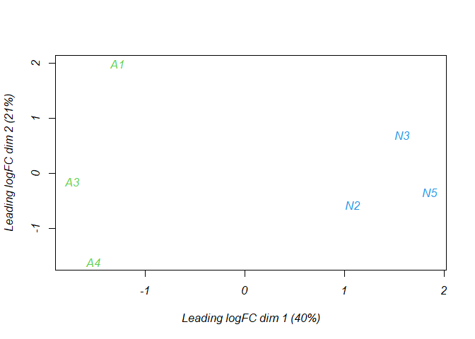

[figure not shown]

```r
# definiendo los colores de cada muestra
fnColors=c(3,3,3,4,4,4)
# graficando
plotMDS(dge,col=fnColors)
```

## Analisis de genes

Una vez que se normalizaron los datos, se hace el cálculo de la dispersión de los genes entre las muestras. Se pueden realizar dos tipos de cálculos de la dispersión de los genes, la denominada dispersión común y la dispersión por gen.

```r
## dispersión común
dge <- estimateCommonDisp(dge)
dge$common.dispersion
```

```
## [1] 0.111521
```

```r
## Calculando dispersión entre las muestras para cada gene
dge <- estimateTagwiseDisp(dge)
head(dge$tagwise.dispersion)
```

```
## [1] 0.05992615 0.13076115 0.17133249 0.17914677 0.15232939 0.06214078
```

edgeR utiliza el método de máxima verosimilitud condicional ajustada por cuantiles (qCML) para el análisis de expresiones de diseño unifactorial. El método qCML utiliza el pseudoconteo para ajustar el tamaño de la biblioteca para todas las muestras. edgeR calcula internamente el pseudoconteo para agilizar el análisis de la estimación de la dispersión binomial negativa (NB) y la prueba exacta para la comparación por pares.

La dispersión se estima mediante la función estimateDisp(). Estima las dispersiones comunes y por gen en una sola ejecución.

```r
dge <- estimateDisp(y = dge)
```

```
## Using classic mode.
```

```r
dge
```

```
## An object of class "DGEList"
## $counts
##                  A1           A3           A4           N2          N3
##        478589.54926 367454.62194 305938.08643 278127.58757 449034.0716
## A1BG      122.83400    102.47410    137.46870    108.51428    189.5627
## A2ML1      14.35049     16.31696     12.27264     16.40076     18.5124
## A2MP1      18.43410     49.00000     18.53930     34.77410    119.0330
## A4GALT     14.44120     27.21150     16.82380     21.45320     45.5909
##                  N5
##        271224.91294
## A1BG      126.14290
## A2ML1       8.75645
## A2MP1      70.59480
## A4GALT     18.34270
## 12652 more rows ...
##
## $samples
##                    group lib.size norm.factors
## A1   Adult_CD4_+_T_Cells 12607305    0.9941385
## A3   Adult_CD4_+_T_Cells 20380768    1.0070973
## A4   Adult_CD4_+_T_Cells 15889283    0.9969299
## N2 Neonate_CD4_+_T_Cells 17858704    1.0123251
## N3 Neonate_CD4_+_T_Cells 33675446    1.0249615
## N5 Neonate_CD4_+_T_Cells 20816518    0.9655827
##
## $common.dispersion
## [1] 0.111574
##
## $pseudo.counts
##                  A1           A3           A4           N2           N3
##        735607.90582 344877.36914 372064.26092 296365.18651 250617.37464
## A1BG      188.25820     96.08699    167.09636    115.63159    105.62975
## A2ML1      21.69971     15.28952     15.02067     17.40055     10.12902
## A2MP1      28.59982     46.07750     22.77497     37.14157     66.68707
## A4GALT     22.28225     25.55837     20.54479     22.85845     25.64587
##                  N5
##        2.599472e+05
## A1BG   1.209047e+02
## A2ML1  8.359685e+00
## A2MP1  6.768561e+01
```

[output cut: 14 more lines]

```
## [1] 0.8330862
##
## $tagwise.dispersion
## [1] 0.07209816 0.10150268 0.11680105 0.14801477 0.08850345
## 12652 more elements ...
##
## $span
## [1] 0.2971391
##
## $trended.dispersion
## [1] 0.04454956 0.16413002 0.23150570 0.22533959 0.23934962
## 12652 more elements ...
##
## $trend.method
## [1] "locfit"
```

Visualización de la dispersión

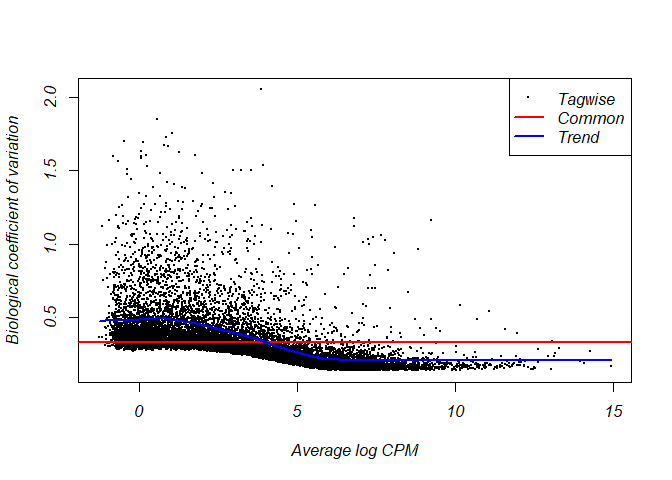

```r
plotBCV(dge)
```

Una vez que se hizo la normalización de los datos y el cálculo de la dispersión de los genes, se puede efectuar el cálculo de la expresión diferencial, utilizando la función exactTest.

```r
# Realizar la prueba exacta (Exact Test) para expresión diferencial
# entre las dos condiciones: Neonate vs Adult.
# Esta prueba usa un modelo binomial negativo para evaluar si los conteos
# de cada gen difieren significativamente entre los grupos.
et = exactTest(dge,pair=c("Neonate_CD4_+_T_Cells","Adult_CD4_+_T_Cells"))

et
```

```
## An object of class "DGEExact"
## $table
##              logFC     logCPM      PValue
##         0.84807046 14.2547431 0.007945995
## A1BG    0.39697387  2.7959333 0.312374878
## A2ML1   0.53168490 -0.2418685 0.331796380
## A2MP1  -0.81147521  1.2937109 0.104872049
## A4GALT  0.04514471  0.3372389 0.960220857
## 12652 more rows ...
##
## $comparison
## [1] "Neonate_CD4_+_T_Cells" "Adult_CD4_+_T_Cells"
##
## $genes
## NULL
```

## 🧠 ¿Qué hace exactTest()?

Compara los dos grupos definidos (pair) usando un test exacto similar al test exacto de Fisher, pero adaptado a conteos RNA-seq modelados con una distribución binomial negativa.

Usa la dispersión estimada previamente (estimateDisp) para modelar la variabilidad entre réplicas.

Calcula para cada gen:

logFC: log₂ fold change (diferencia en expresión entre grupos).

logCPM: abundancia promedio.

PValue: significancia estadística sin corregir.

🧬 Resumen del flujo de trabajo RNA-seq

1️⃣ Importación de archivos de cuantificación (.tsv) 2️⃣ Creación de la tabla de correspondencia (tx2gene) 3️⃣ Importación de datos con tximport 4️⃣ Asignación de nombres de muestras y condiciones experimentales 5️⃣ Creación del objeto DGEList (edgeR) 6️⃣ Normalización de datos con TMM 7️⃣ Visualización de calidad mediante MDS Plot 8️⃣ Análisis de expresión diferencial con exactTest

Podemos interrogar los genes más diferencialmente expresados toptags :

```r
topTags(et)
```

```
## Comparison of groups:  Adult_CD4_+_T_Cells-Neonate_CD4_+_T_Cells
##               logFC   logCPM       PValue          FDR
## SMC4      -2.609832 8.615364 2.003139e-44 2.535373e-40
## MID2       6.913275 2.405555 9.125177e-32 5.774868e-28
## SELENOM    3.427237 4.433715 4.555456e-29 1.921947e-25
## AUTS2     -3.957375 7.018281 7.795298e-27 2.466627e-23
## CDCA7     -3.621923 4.787070 1.185259e-26 3.000365e-23
## KIF21A     3.863285 3.321252 3.042787e-26 6.418759e-23
## CACNA1I    2.647926 7.873999 1.819653e-25 3.290193e-22
## CDC14B     3.609886 4.305638 2.472691e-25 3.912106e-22
## RAB11FIP5  3.240406 4.335855 2.760598e-24 3.882321e-21
## ZNF154    -2.568373 5.382936 8.349135e-24 1.056750e-20
```

```r
summary(decideTests(object = et, lfc = ))
```

```
##        Adult_CD4_+_T_Cells-Neonate_CD4_+_T_Cells
## Down                                         572
## NotSig                                     11600
## Up                                           485
```

Vamos a asignar los resultados del cálculo de expresión diferencial al objeto resEdgeR y posteriormente seleccionaremos los genes que consideramos diferencialmente expresados

```r
resEdgeR<-topTags(et, n=Inf)$table
dim(resEdgeR)
```

```
## [1] 12657     4
```

```r
head(resEdgeR)
```

```
##             logFC   logCPM       PValue          FDR
## SMC4    -2.609832 8.615364 2.003139e-44 2.535373e-40
## MID2     6.913275 2.405555 9.125177e-32 5.774868e-28
## SELENOM  3.427237 4.433715 4.555456e-29 1.921947e-25
## AUTS2   -3.957375 7.018281 7.795298e-27 2.466627e-23
## CDCA7   -3.621923 4.787070 1.185259e-26 3.000365e-23
## KIF21A   3.863285 3.321252 3.042787e-26 6.418759e-23
```

Filter the genes based on the LFC and adjusted p-Value (|LFC|>=1 and p-adj<0.05).

```r
padj.cutoff <-0.05
lfc.cutoff<- 1
lfc_0 <-0

res_df1 <- resEdgeR %>% data.frame()%>% rownames_to_column(var="gene") %>% as_tibble()

sig1<- res_df1 %>% filter(FDR<= padj.cutoff & abs(logFC) >= lfc.cutoff)
dim(sig1)
```

```
## [1] 756   5
```

```r
sig_Neo <- res_df1 %>% filter(FDR<= padj.cutoff & logFC > lfc.cutoff)
dim(sig_Neo)
```

```
## [1] 335   5
```

```r
sig_Adul <- res_df1 %>% filter(FDR<= padj.cutoff & logFC <= -lfc.cutoff)
dim(sig_Adul)
```

```
## [1] 421   5
```

```r
write.table(sig1,file="Neo_vs_Adultos_DiffExp_edgeR.txt",sep="\t", quote=F)
```

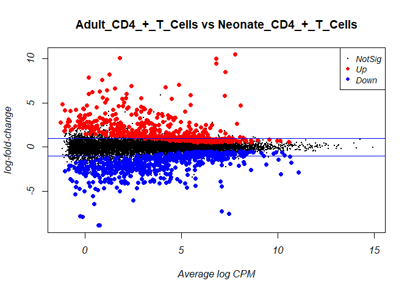

```r
plotMD(object = et)
abline(h=c(-1, 1), col="blue")
```

## Volcan plot

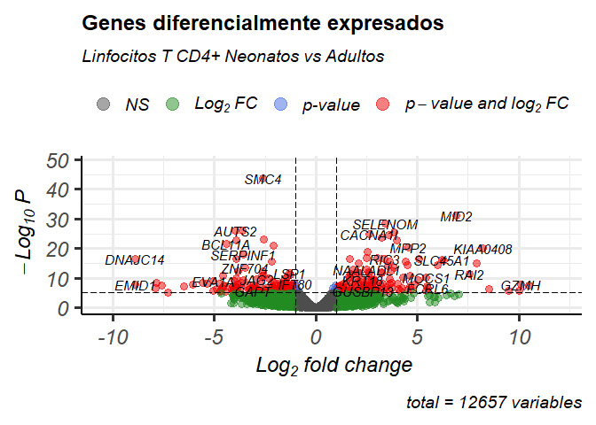

```r
color_volcan <- EnhancedVolcano(resEdgeR,
                lab = rownames(resEdgeR),
                title = "Genes diferencialmente expresados",
                subtitle = "Linfocitos T CD4+ Neonatos vs Adultos",
                x = 'logFC',
                y = 'PValue',
                pointSize = 3.0,
                labSize = 4.0)

color_volcan
```